# 589Project

# 13. Morisita’s Index

```r
# define a rectangular window for Morisita's Index
bbox <- st_bbox(coho_sf)
w <- owin(xrange = c(bbox$xmin, bbox$xmax), yrange = c(bbox$ymin, bbox$ymax))
coho_ppp_rect <- ppp(x = st_coordinates(coho_sf)[,1],
                y = st_coordinates(coho_sf)[,2],
                window = w)
```

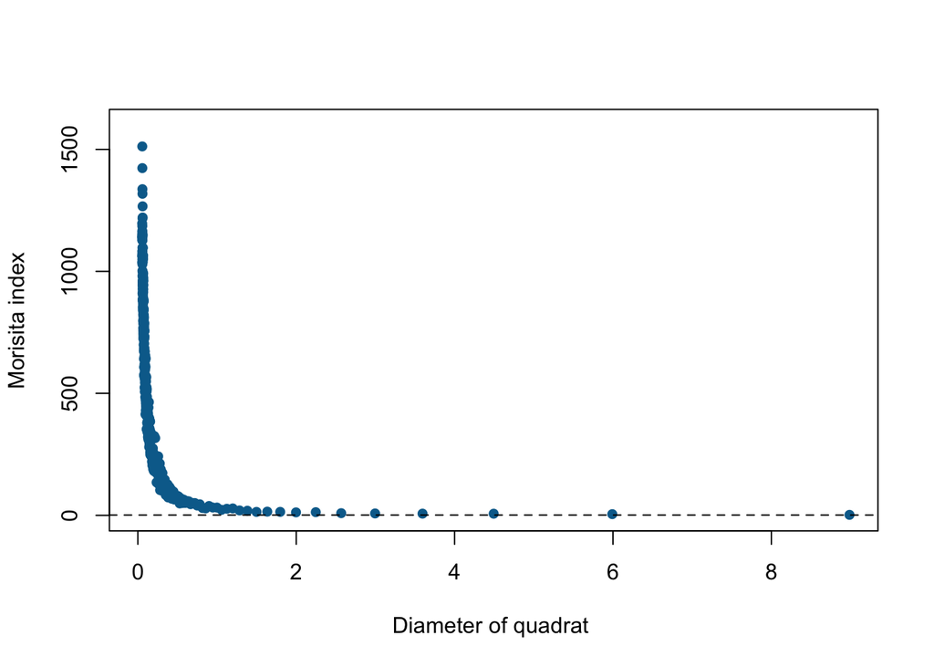

```r
miplot(coho_ppp_rect, ylim = c(0, 1600), main = "", pch = 16, col = "#046C9A")
```

Extreme Clumping at Small Scales: The very high Morisita’s Index values at small quadrat sizes suggest that Coho salmon are extremely clumped or aggregated at these scales. This could be reflective of spawning behavior, where Coho salmon congregate in specific areas that provide suitable conditions for laying eggs. It might also indicate areas of high habitat quality where salmon prefer to stay, such as regions with ample food supply, appropriate substrate for spawning, or optimal water temperatures.

Steep Decline in Index with Quadrat Size: As the size of the quadrats increases, the index rapidly decreases, indicating that the clumping is not as intense over larger areas. This could mean that while Coho salmon are very likely to be found close together in small, localized areas (e.g., specific parts of a stream or river), they are more evenly distributed when you consider larger stretches of habitat. This pattern is consistent with the behavior of salmon which may have specific, localized spawning sites but are more dispersed across their overall range.

Stabilization of the Index: For larger quadrat sizes, where the Morisita’s Index values approach and just exceed 1, the spatial distribution of salmon begins to resemble a random pattern. This transition from clumped to a seemingly random distribution at larger scales may suggest that across the broader regions of British Columbia, Coho salmon do not show strong preferential clustering; instead, their distribution is dictated by the availability of suitable habitats scattered throughout the region.

Biological and Environmental Implications: The results may be significant for conservation and management strategies. The initial high clumping could inform biologists and conservationists about critical areas that need protection, especially during the spawning season. This might include protecting specific streams or river segments, managing human activities such as fishing and development, and monitoring water quality and flow conditions.

Consideration of Scale: The fact that the index stabilizes around 1 at larger quadrat sizes is also informative for resource management. It suggests that at the scale of larger river systems or multiple stream networks, Coho salmon might not exhibit strong patterns of aggregation, perhaps due to the vastness and variability of available habitats.